# Assignment 1: Maglev Trains

Programming for Engineers (ENGG1001)  
**Due: 27 March 2026, 15:00 GMT+10**

Published

March 31, 2026

# Introduction

Magnetic levitation (maglev) train technology is an important innovation that enables a train to run more smoothly and faster than a conventional rolling stock train. Current experimental maglev trains have been clocked travelling at over 600km/hr and there are plans to implement systems which run even faster.

Maglev trains have several advantages:

1. there are no energy losses from rolling friction
2. the absence of train to track contact enables a smoother ride
3. they tend to be very well designed aerodynamically because air resistance is their key area of energy loss
4. they can travel at very high speeds
5. the absence of rotating parts such as motors reduces fatigue and increases lifespan
6. they have relatively low operating costs because of their energy efficiency
7. they tend to be environmentally friendly.

It should be noted that for maglev trains the constituent wires in the electromagnets need to be superconducting and this requires substantial cooling. Fortunately, in 1986 it was discovered that superconduction could be achieved with certain ceramic materials at around 77 degrees Kelvin, much higher than the temperatures needed for metal based superconductors. A temperature of 77 degrees Kelvin can be achieved readily by cooling with liquid nitrogen, which is relatively cheap.

While maglev trains have many advantages, they also have a key disadvantage – the cost of developing the required infrastructure. To see what sort of infrastructure is required, have a read of this [article on maglev trains](https://www.intechopen.com/chapters/1206683).

In this assignment you will write some code to investigate and quantify some of the differences between maglev and conventional trains.

The forces that act on a train can be observed in the following diagram.

<sub>F<sub>thrust</sub></sub> ←

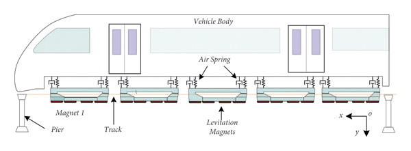

→ <sub>F<sub>drag</sub></sub>

∑ F = F<sub>thrust</sub> - F<sub>drag</sub> = ma

Figure 1: Forces acting on a maglev train (Image source: [researchgate.net](https://www.researchgate.net/figure/Side-view-of-medium-speed-maglev-train_fig6_355948395))

From this force diagram and a little bit of physics (which we don’t need to go into here) we can derive the following equations describing the acceleration, velocity, and position of the train as a function of time:
$$a_i = \frac{1}{m} (F_{thrust} - \underbrace{(\mu \cdot m \cdot G + \frac{1}{2} \rho v_i^2 \cdot A_{ref} \cdot C_D)}_{F_{drag}})$$
$$v_{i+1} = v_i + a_i \cdot \Delta t$$
$$x_{i+1} = x_i + v_i \cdot \Delta t + \frac{1}{2} a_i \cdot \Delta t^2$$

Where:

- $m$ is the mass of the train in kg
- $F_{thrust}$ is the applied train engine force in N
- $\mu$ is the coefficient of friction
- $A_{ref}$ is the aerodynamic train reference area
- $\rho$ is the air density
- $C_D$ is the drag coefficient
- $G = 9.81 \, \text{m/sec}^2$ is the acceleration due to gravity
- $\Delta t$ is the time increment
- $a_i$ is the acceleration at time step $i$
- $v_i$ is the velocity at time step $i$
- $x_i$ is the position at time step $i$

For a maglev train $\mu$ will be assumed to be 0, since such a train has no frictional resistance. Conventional trains typically need to have a $\mu$ value around 0.5 to be safe enough to stop safely under all weather conditions. This is important because the $\mu$ value tends to drop substantially when it is wet, snowing or hailing.

It is required that you write a program which compares the speeds and accelerations achievable for maglev trains compared to conventional trains.

To help structure your program, the functionality has been broken into a number of tasks. Follow these tasks in order, and test the code as you progress with building the program.

Download the files below to get started.

**Important**

You must write your code in the file `a1.py`. Submit only this and your ai statement file `ai_statement.pdf` to gradescope. Do not submit any other files. If you submit any other files, it could disrupt the autograder and affect your functionality marks. More details surrounding this can be found at the end of the assignment.

You can use the `a1_support.py` file to help you with your code, but do not copy-paste any code from that file into `a1.py`, instead you should `import` it with a `import` statement as shown in the base `a1.py` template. If you do copy paste code, you will lose style marks for repeated code and you may also lose marks for readability and documentation.

```
a1.py
```

```python
from a1_support import *

__author__ = "<Insert name here>"
__date__ = "<Insert date here>"
__email__ = "<Insert email here>"

# Your code goes here



if __name__ == "__main__":
    # You can use this section to test your code
    pass
```

```
a1_support.py
```

```python
import matplotlib.pyplot as plt

GRAVITY = 9.81  # m/s^2

COLUMN_WIDTH = 25
TABLE_CHAR = "*"

HELP_MESSAGE = """Commands:
    - h : Display this help message
    - r : read test data from the specified file
    - p {time_period} {mu_init} {step_size} {num_steps} : print final speeds table for friction coefficients
    - s {target_velocity}: simulate the train until it reaches the target velocity
    - q: quit the program"""


def read_data(directory: str, filename: str) -> tuple[float, ...]:
    """Read simulation parameters from a data file.

    Parameters
    ----------
    directory : str
        The directory where the data file is located
    filename : str
        The name of the data file to read from

    Returns
    -------
    tuple[float, ...]
        A tuple containing all the simulation parameters in the following order:
        mass, thrust, mu, rho, area_ref, drag_coeff, velocity_init, position_init, delta_t
    """
    with open(f"{directory}/{filename}", 'r') as file:
        line = file.readline()

    params = tuple(float(item) for item in line.split(','))
    return params

def plot_train(velocities: tuple[float, ...], positions: tuple[float, ...], delta_t: float) -> None:
    """Plot the position and velocity of the train over time.

    Parameters
    ----------
    positions : tuple[float, ...]
        A tuple containing the position of the train at each time step [meters]
    velocities : tuple[float, ...]
        A tuple containing the velocity of the train at each time step [m/s]

    Returns
    -------
    None
    """
    time_steps = [i * delta_t for i in range(len(positions))]

    fig, ax = plt.subplots(2, 1, sharex=True)

    # Plot Position
    ax[0].plot(time_steps, positions, marker='o')
    ax[0].set_title('Train Position Over Time')
    ax[0].set_ylabel('Position (m)')
    ax[0].grid()

    # Plot Velocity
    ax[1].plot(time_steps, velocities, marker='o', color='orange')
    ax[1].set_title('Train Velocity Over Time')
    ax[1].set_xlabel('Time (s)')
    ax[1].set_ylabel('Velocity (m/s)')
    ax[1].grid()

    fig.suptitle('Train simulation results')

    plt.tight_layout()
    plt.show()
```

Here are some data files which you will use in the final task of your assignment. The data values from left to right are: `mass`, `thrust`, `mu`, `rho`, `area_ref`, `drag_coeff`, `velocity_init`, `position_init`, `delta_t`. The maglev.txt file contains parameters for a maglev train and the standard.txt file contains parameters for a conventional train.

```
maglev.txt
```

```
5e4,5e5,0,1,12,1,0,0,0.2
```

```
standard.txt
```

```
5e4,5e5,0.5,1,12,5,0,0,0.2
```

# Part A: Calculating Train Dynamics

## Task 1 (0.5 marks)

Write the function `calculate_acceleration` which calculates the acceleration of the train at a given time step. The function description is below:

```python
def calculate_acceleration(mass: float, thrust: float, mu: float,
                           rho: float, area_ref: float,
                           drag_coeff: float, velocity: float) -> float:
    """Calculates the acceleration of a train

    Parameters
    ----------
    mass : float
        The mass of the train [kilograms]
    thrust : float
        The thrust force [newtons]
    mu : float
        The coefficient of friction [unitless]
    rho : float
        The air density [kilograms per cubic metre]
    area_ref : float
        aerodynamic train reference area [square metres]
    drag_coeff : float
        The drag coefficient [unitless]
    velocity : float
        The velocity of the train [metres per second]

    Returns
    -------
    float
        The acceleration of the train [metres per second squared]
    """
```

A sample usage of the function is also shown below:

```python
mass = 5e4
thrust = 5e5
mu = 0
rho = 1
area_ref = 12
drag_coeff = 2
velocity = 0
acceleration = calculate_acceleration(mass, thrust, mu,
                                       rho, area_ref,
                                       drag_coeff, velocity)
print(f"Maglev Train acceleration: {acceleration}")

mu = 0.5 # change to conventional train friction coefficient
acceleration = calculate_acceleration(mass, thrust, mu,
                                       rho, area_ref,
                                       drag_coeff, velocity)
print(f"Conventional Train acceleration: {acceleration}")
```

Output

```
Maglev Train acceleration: 10.0
Conventional Train acceleration: 5.095000000000001
```

**Tip**

To make testing easier, you should copy-paste the code example above into the `if __name__ == "__main__":` section of your `a1.py` file to test your function. This way, everytime you run your program, it will run those lines of code and you can see the output.

## Task 2 (0.5 marks)

Write the function `calculate_velocity_position()` which calculates the new velocity and position of the train at each time step based upon the current `acceleration`, `velocity_init`, and `position_init`. The function description is below:

```python
def calculate_velocity_position(velocity_init: float, position_init: float,
                                acceleration: float, delta_t: float) -> tuple[float, float]:
    """Calculates the new velocity and position of the train

    Parameters
    ----------
    velocity_init : float
        The initial velocity of the train [metres per second]
    position_init : float
        The initial position of the train [metres]
    acceleration : float
        The current acceleration of the train [metres per second squared]
    delta_t : float
        The time increment [seconds]

    Returns
    -------
    tuple[float, float]
        A tuple containing velocity and position of the train at the next time step
        [metres per second, metres]
    """
```

A sample usage of the function is also shown below:

```python
mass = 5e4
thrust = 5e5
mu = 0
rho = 1
area_ref = 12
drag_coeff = 2
velocity = 0
acceleration = calculate_acceleration(mass, thrust, mu,
                                       rho, area_ref,
                                       drag_coeff, velocity)

delta_t = 1  # 1 second time step
position = 0  # starting at position 0 metres
new_velocity, new_position = calculate_velocity_position(velocity,
                                                          position,
                                                          acceleration,
                                                          delta_t)
print(f"Maglev velocity: {new_velocity}, position: {new_position}")

mu = 0.5 # change to conventional train friction coefficient
acceleration = calculate_acceleration(mass, thrust, mu,
                                       rho, area_ref,
                                       drag_coeff, velocity)
new_velocity, new_position = calculate_velocity_position(velocity,
                                                          position,
                                                          acceleration,
                                                          delta_t)
print(f"Conventional train velocity: {new_velocity}, position: {new_position}")
```

Output

```
Maglev velocity: 10.0, position: 5.0
Conventional train velocity: 5.095000000000001, position: 2.5475000000000003
```

## Task 3 (1 mark)

Write the function `simulate_train()` which simulates the train motion until the velocity reaches a specified target velocity `target_velocity`. The function description is below:

```python
def simulate_train(mass: float, thrust: float, mu: float,
                   rho: float, area_ref: float, drag_coeff: float,
                   velocity_init: float, position_init: float,
                   delta_t: float, target_velocity: float) -> tuple[tuple[float, ...], tuple[float, ...]]:
    """Simulates the train motion until the target velocity is reached
    """
```

A sample usage of the function is also shown below:

```python
mass = 5e4
thrust = 5e5
mu = 0.5
rho = 1
area_ref = 12
drag_coeff = 2
delta_t = 0.2
target_velocity = 70
velocities, positions = simulate_train(mass, thrust, mu,
                                        rho, area_ref, drag_coeff,
                                        0, 0,
                                        delta_t, target_velocity)
print(velocities)
print(positions)
```

Output

```
(0, 1.0190000000000001, 2.0379501586720004, 3.056750803111237, 4.075302304288566, 5.093505116022741, 6.111259813893128, 7.128467134060508, 8.145028011963802, 9.16084362086065, 10.175815410180048, 11.18984514365547, 12.202834937207198, 13.214687296542971, 14.225305154446392, 15.234591907723011, 16.24…
(0, 0.10190000000000003, 0.4075950158672001, 0.917065112045524, 1.6302704227855043, 2.547151164816635, 3.6676276578082216, 4.9916003526035855, 6.518949867206016, 8.249537030488462, 10.183202933592531, 12.319768988976081, 14.659036997062348, 17.200789220437365, 19.944788465536302, 22.890778171753244,…
```

**Tip**

You should consider using the previous functions you have already written to help you implement this function.

Also note that the docstring for this function is incomplete. You should complete the docstring by following the format of the previous functions and describing the parameters and return types clearly. This is important for the style mark of your assignment, so make sure to do it properly. All future functions will not have ANY docstring comments, so you will need to write your own.

## Task 4 (1 mark)

Write a function `compute_final_speed` which computes the final speed for a train for a given time period. The function description is below:

```python
def compute_final_speed(mass: float, thrust: float, mu: float,
                        rho: float, area_ref: float, drag_coeff: float,
                        velocity_init: float, position_init: float,
                        delta_t: float, time_period: float) -> float:
```

A sample usage of the function is also shown below:

```python
mass = 5e4
thrust = 5e5
mu = 0.5
rho = 1
area_ref = 12
drag_coeff = 2
delta_t = 0.2
time_period = 10
final_speed = compute_final_speed(mass, thrust, mu,
                                   rho, area_ref, drag_coeff,
                                   0, 0,
                                   delta_t, time_period)
print(final_speed)
```

Output

```
49.927669399568074
```

# Part B: Making it User Friendly

## Task 5 (1.5 marks)

In this task, you are required to write a function to print out a table analysing the effects of varying $\mu$ on the final speed of the train. The function description is below:

```python
def print_table(mass: float, thrust: float, mu_init: float,
                step_size: float, num_steps: int,
                rho: float, area_ref: float,
                drag_coeff: float, velocity_init: float,
                position_init: float, delta_t: float,
                time_period: float) -> None:
```

A sample usage of the function is shown below:

```python
mass = 5e4
thrust = 5e5
mu_init = 0
step_size = 0.1
num_steps = 6
rho = 1
area_ref = 12
drag_coeff = 2
velocity_init = 0
position_init = 0
delta_t = 0.2
time_period = 10
print_table(mass, thrust, mu_init,
             step_size, num_steps,
             rho, area_ref,
             drag_coeff, velocity_init,
             position_init, delta_t,
             time_period)
```

Output

```
*        Final Speeds Table after 10 seconds        *
*     Friction Coeff      *    Final Speed (m/s)    *
*          0.000          *          94.47          *
*          0.100          *          85.82          *
*          0.200          *          77.04          *
*          0.300          *          68.13          *
*          0.400          *          59.10          *
*          0.500          *          49.93          *
```

**Tip**

You will need to use `f-strings` here to format the table output. Observe carefully the number of decimal places that are shown in the example output.

## Task 6 (2.5 marks)

For this task, you are required to write a basic terminal user interface (TUI) function called `main()` which has no parameters or returns. This function allows the user to easily interact with the other functions that you have written. Your TUI **MUST** match the following example **exactly**, otherwise the autograder will not accept your solution. Note that user inputs are shown in black and what the program outputs are shown in blue.

main()

Please enter a command: h

Commands:

- h : Display this help message

- r : read test data from the specified file

- p {time_period} {mu_init} {step_size} {num_steps} : print final speeds table for friction coefficients

- s {target_velocity}: simulate the train until it reaches the target velocity

- q: quit the program

Please enter a command: r

Please enter the directory: data

Please enter the filename: maglev.txt

Data loaded successfully.

Please enter a command: p 60 0 0.1 6

*****************************************************

* Final Speeds Table after 60 seconds *

*****************************************************

* Friction Coeff * Final Speed (m/s) *

*****************************************************

* 0.000 * 279.95 *

* 0.100 * 263.94 *

* 0.200 * 246.82 *

* 0.300 * 228.35 *

* 0.400 * 208.23 *

* 0.500 * 186.05 *

*****************************************************

Please enter a command: s 70

Please enter a command: r

Please enter the directory: data

Please enter the filename: standard.txt

Data loaded successfully.

Please enter a command: p 60 0 0.1 6

*****************************************************

* Final Speeds Table after 60 seconds *

*****************************************************

* Friction Coeff * Final Speed (m/s) *

*****************************************************

* 0.000 * 129.08 *

* 0.100 * 122.57 *

* 0.200 * 115.69 *

* 0.300 * 108.37 *

* 0.400 * 100.50 *

* 0.500 * 91.92 *

*****************************************************

Please enter a command: s 70

Please enter a command: q

Are you sure? (y/n): n

Please enter a command: q

Are you sure? (y/n): y

**Note**

In this interaction, we are assuming that the data files are located in a folder called `data` which is in the same directory as your `a1.py` file.

When the user types in the command `s 70` when `maglev.txt` is loaded, the program should simulate the train with the maglev parameters until it reaches a velocity of 70 m/s. It should also produce a plot that matches the one below:

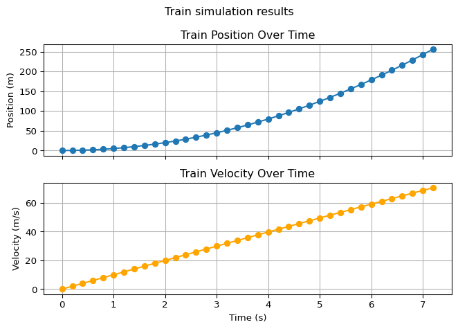

Figure 2: Sample plot for command `s 70` with maglev parameters

Likewise `standard.txt` is loaded and the user command is `s 70`, the program should simulate the train with the standard parameters until it reaches a velocity of 70 m/s. It should also produce a plot that matches the one below:

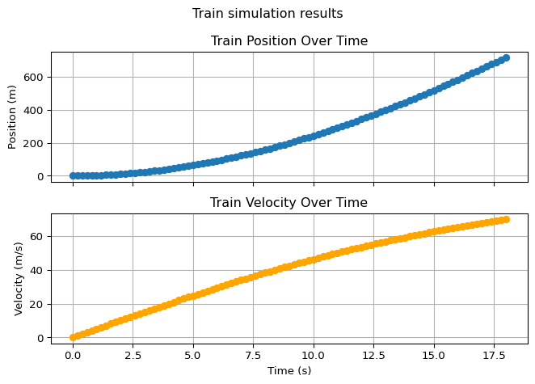

Figure 2: Sample plot for command `s 70` with standard parameters

Your TUI should also handle invalid inputs gracefully. See the example below:

main()

Please enter a command: k

Please enter a valid command. Type 'h' for help.

Please enter a command: hg

Please enter a valid command. Type 'h' for help.

Please enter a command: p 60 0 0.1 6

Error: No data loaded. Please load data using the 'r' command first.

Please enter a command: s

Error: No data loaded. Please load data using the 'r' command first.

Please enter a command: s p

Error: No data loaded. Please load data using the 'r' command first.

Please enter a command: s 70

Error: No data loaded. Please load data using the 'r' command first.

Please enter a command: p 60

Error: No data loaded. Please load data using the 'r' command first.

Please enter a command: r

Please enter the directory: data

Please enter the filename: maglev.txt

Data loaded successfully.

Please enter a command: p 60

Error: Invalid number of arguments for 'p' command. Type 'h' for help.

Please enter a command: s

Error: Invalid number of arguments for 's' command. Type 'h' for help.

Please enter a command: s p

Error: All arguments must be numbers. Type 'h' for help.

Please enter a command: p 60 0 0.1s 6

Error: All arguments must be numbers. Type 'h' for help.

Please enter a command: q

Are you sure? (y/n): n

Please enter a command: q

Are you sure? (y/n): y

**Important**

You do not need to account for the errors of invalid file paths when reading data files. You can assume that the user will always provide a valid file path.

You will need to check whether the user has loaded data before allowing them to use the `p` and `s` commands. If they have not loaded data, you should print out the error message shown in the example above.

You will also need to check whether the user has provided the correct number of arguments, and the correct type of arguments for the `p` and `s` commands. If they have not, you should print out the error messages shown in the example above.

**Tip**

To help you implement write `main()`, have a look at the `read_data()` and `plot_train()` functions provided in the `a1_support.py` file. Read the docstrings for these functions to understand how to use them.

# Writing Your Code

# Design

You are expected to use good programming practice in your code, and you must incorporate at least the functions described in the previous part of the assignment sheet.

# Assessment Marking

The maximum achievable mark for this assignment is 10 marks.

## Functionality assessment: 7 marks

The functionality will be marked out of 7. Your assignment will be put through a series of tests and your functionality mark will be automatically generated by the autograder. This grade is NOT overwritten. So if you have a syntax error in your code which causes it to fail all the tests even though the rest of your code is fine, you will still get 0 marks.

Your final functionality mark for the assignment is based on the most recent submission. Note that functionality tests are automated and so string outputs need to exactly match what is expected. **Do not leave it until the last minute** because it generally takes time to get your code to pass the tests.

## Code Style Assessment: 3 marks

The style of your assignment will be assessed by one of the tutors, and you will be marked according to the style rubric below. The style mark will be out of 3.

| Criteria | Proficient (100%) | Competent (50%) | Novice (0%) |
| --- | --- | --- | --- |
| **READABILITY** **Program structure** *Weight: 10.00%* | Logical modular blocks are used to make the code easy to understand. Constants help to improve code readability. All code line widths are less than 100 characters | A mixture of logical modular blocks is used along with some poor code structure. Some lines exceed 100 characters | Poor code structure is used which makes the code difficult to read. Many lines exceeded 100 characters |
| **Identifier names** *Weight: 10.00%* | All variable and function names are informative, and well chosen, increasing readability of the code. | Most identifier names are informative and well chosen, improving code readability somewhat. | Most identifier names are poorly chosen. |
| **Repeated code** *Weight: 10.00%* | Repeated code has been avoided. Code that was included in the support file was used appropiately and not copy-pasted into the main file | Some code is repeated unnecessarily. Or some code from the support file was copied into the main file | Large amounts of code are repeated unnecessarily. |
| **Variable scope** *Weight: 10.00%* | Only local variables have been used in functions. Global variables have not been used. |  | Global variables have been used. |
| **SIMPLICITY** **Algorithmic logic** *Weight: 10.00%* | Code is brief but clear, and has no logical errors. | Code is occasionally too complex or has minor logical errors. | Code is overly complex or has major errors. |
| **Control structures** *Weight: 10.00%* | Control structures are used to good effect. | A small number of control structures are unnecessarily complex. | Many control structures are poorly designed (eg. excessive nesting and/or looping). |
| **DOCUMENTATION** **All modules and functions have informative docstring comments** *Weight: 20.00%* | All docstrings are accurate and descriptive, and clearly show how parameters and return types should be used. | Almost all docstrings are accurate and reasonably clear descriptions of how module/function is to be used. Almost all parameters and return types are described clearly. | Several docstrings are inaccurate or unclear, or absent. Some parameters and return types are unclear. |
| **Comments are clear and concise, without excessive or extraneous text** *Weight: 10.00%* | Almost all comments enhance the comprehensibility of the code. Comments almost never repeat information already apparent in the code. |  | Many comments are unnecessary to the comprehension of the code. Alternatively, many comments are overly verbose. |
| **Significant blocks of program logic are clearly explained by comments** *Weight: 10.00%* | Important or complex segments of logical flow (e.g. major loops or conditionals) are almost always clearly explained/summarised. Almost no stating of the obvious (eg. a loop iterates over a sequence). |  | Some important or complex blocks of logic are explained/summarised poorly. Alternatively, some unimportant blocks of code are given excessive coverage in the comments. |

## Assignment Submission

You must submit 2 files to Gradescope: `a1.py` and `ai_statement.pdf`. You will write your code solution in `a1.py` and you will write your usage of ai statement in `ai_statement.pdf`. If you **do not submit** `ai_statement.pdf`, or if the file is **empty**, you will automatically receive **0%** for the assignment, even if your code is perfect.

As such, even if you didn’t use ai for this assignment, you must declare that in your assignment statement. The layout of this statement is up to you, as it is not assessed directly. The following link is an official uq guidance on how to structure your ai statement: [UQ Library](https://guides.library.uq.edu.au/referencing/acknowledging-and-referencing-ai)

You are permitted to submit as many times as necessary to the autograder; only your final submission will be marked. We recommend submitting early and often; submit each completed task to the autograder as soon as it works.

According to the course ECP, late submissions will be penalised by 10% per day for up to 3 days. After 3 days (72 hours), you will recieve a mark of zero. Note that this assignment is not available for an extension, and that there are no exceptions.